# Forecasting and simulating A&E demand in BNSSG and Gloucestershire

Technical report

Author

Iyeose Simon

Published

November 2026

# 1 Summary

This report forecasts Type 1 (major emergency department) A&E attendances for the acute trusts serving Bristol, North Somerset and South Gloucestershire (BNSSG) and Gloucestershire, and simulates what January 2028 demand means for Type 1 4-hour performance. It answers three questions a commissioner planning 2027-28 activity would ask. All 4-hour figures here are **Type 1 only**; they exclude urgent treatment centres and so sit below a trust’s published all-types figure.

**1. Growth and seasonality.** Since Covid, Type 1 demand has grown by about **3.9% a year in Bristol** and **3.9% in Gloucestershire** (95% confidence intervals 3.4% to 4.5% and 3.3% to 4.6%). Attendances are **lower in winter** (December to February) than in summer, by 3.6% in Bristol and 7.3% in Gloucestershire, but the **share of patients admitted is about 6% higher at both trusts**. Winter brings sicker patients, not more of them.

**2. Activity plan for 2027-28.** Plan for **499,600 Type 1 attendances** across the two trusts (80% range 486,000 to 513,100), 5.2% more than the last 12 months: 325,400 in Bristol and 174,200 in Gloucestershire. In back-tests the Gloucestershire models under-forecast by 3.5% on average, so its risk runs upwards.

**3. What it means for capacity.** In a simulation of Gloucestershire’s emergency department in January 2028, the share of Type 1 patients leaving A&E within 4 hours falls from 59.8% (January 2026) to about **47.6%** (range across simulated Januaries 40% to 55%). **One extra clinician from 10:00 to 22:00 adds about 11.1 percentage points** (95% range 6.5 to 15.3) and cuts the average wait to see a clinician by 15 minutes. The department runs close to its capacity limit, so small changes in demand or clinician time have large effects.

# 2 Data

## 2.1 Source

NHS England, *Monthly A&E Attendances and Emergency Admissions*, provider-level CSV files: 103 consecutive months, April 2018 to October 2026. Earlier years (2015-16 to 2017-18) were published as Excel files only and are out of scope.

**The data is frozen.** The raw files are stored in the repository and the cut-off (October 2026) is set in `R/00_config.R`. Every script ignores later months, so a rerun reproduces these results even after NHS England publishes new or revised data. Updating the analysis means moving the cut-off deliberately, which will change every number.

[output not shown]

## 2.2 Data quirks handled

- **Two mergers in Bristol.** Without Weston (RA3), the Bristol series showed a false step of about 140 attendances a day in April 2020. This was found from the first chart (the step did not appear in Gloucestershire) and confirmed in the raw data before fixing.
- **Changing column names.** Files before April 2020 name the Type 1 column `Number of A&E attendances Type 1`; later files drop “Number of”. The cleaning code matches both.
- **Inconsistent link labels.** July 2021’s file is labelled “Monthly July 2021” without “A&E”; the download filter was loosened so it is not skipped.
- **Revisions.** Where a month has been revised, the latest version available at the cut-off is used.
- **Type 1 only.** Urgent treatment centres and other A&E types changed reporting over time, so only major emergency departments are modelled. Type 1 4-hour performance is lower than the all-types figure trusts publish.
- **Days in the month.** Attendances are converted to attendances per day so February’s 28 days do not look like a fall in demand.
- **Covid.** April 2020 to June 2021 is flagged. Growth, seasonality and forecasting use July 2021 onwards.

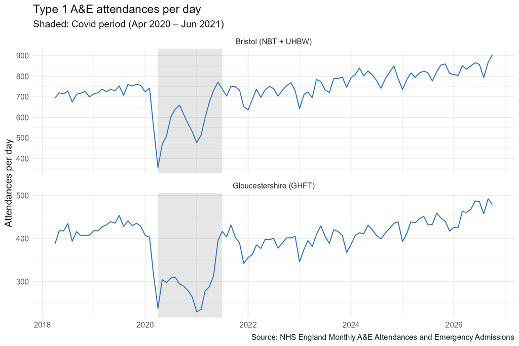

Figure 1: Type 1 attendances per day, both series (shaded: Covid period)

# 3 Question 1: growth and seasonality

## 3.1 Method

Two independent methods were used on July 2021 onwards, so each answer is cross-checked:

- **STL decomposition** splits each series into a smooth trend, a fixed yearly seasonal pattern and a remainder.
- **Regression** of log(attendances per day) on a time trend and calendar-month effects. The time coefficient gives annual growth with a 95% confidence interval; the month coefficients give the seasonal pattern. The same regression on emergency admissions gives the seasonal pattern in admissions, and the two together give the share of patients admitted.

## 3.2 Results

| Measure | Bristol | Gloucestershire |
| --- | --- | --- |
| Growth per year (regression, 95% CI) | 3.9% (3.4% to 4.5%) | 3.9% (3.3% to 4.6%) |
| Growth per year (STL trend) | 3.0% | 2.7% |
| Trend growth, last 12 months (STL) | 5.7% | 7.2% |
| Attendances: winter vs summer (regression) | -3.6% | -7.3% |
| Attendances: winter vs summer (STL) | -4.1% | -7.9% |
| Emergency admissions: winter vs summer | 2.0% | -1.6% |
| Share admitted: winter vs summer | 5.8% | 6.2% |
| Type 1 4-hour performance: winter minus summer | -3.8 points | -1.3 points |
| Attendances per day: pre-Covid to last 12 months | 741 to 843 (13.7%) | 430 to 459 (6.5%) |

Winter = December to February; summer = June to August. Pre-Covid = April 2019 to February 2020.

**Growth.** The regression figure is the one to quote. The STL figure compares only the first and last points of the trend, and July 2021 was inflated by the post-lockdown rebound, which pulls it down. The last-12-months trend growth suggests demand may be accelerating; the forecasting back-tests (section 4) point the same way for Gloucestershire.

**Seasonality.** January is the quietest month for attendances at both trusts; attendances peak in late spring and in October to November. But the share of patients admitted rises in winter at both trusts, by about 5.8% in Bristol and 6.2% in Gloucestershire, and Type 1 4-hour performance is worst in winter. Winter pressure is about how unwell patients are, not the number arriving. Whether waits for beds also lengthen in winter was not measured here: the decision-to-admit figures were used for January only (section 5).

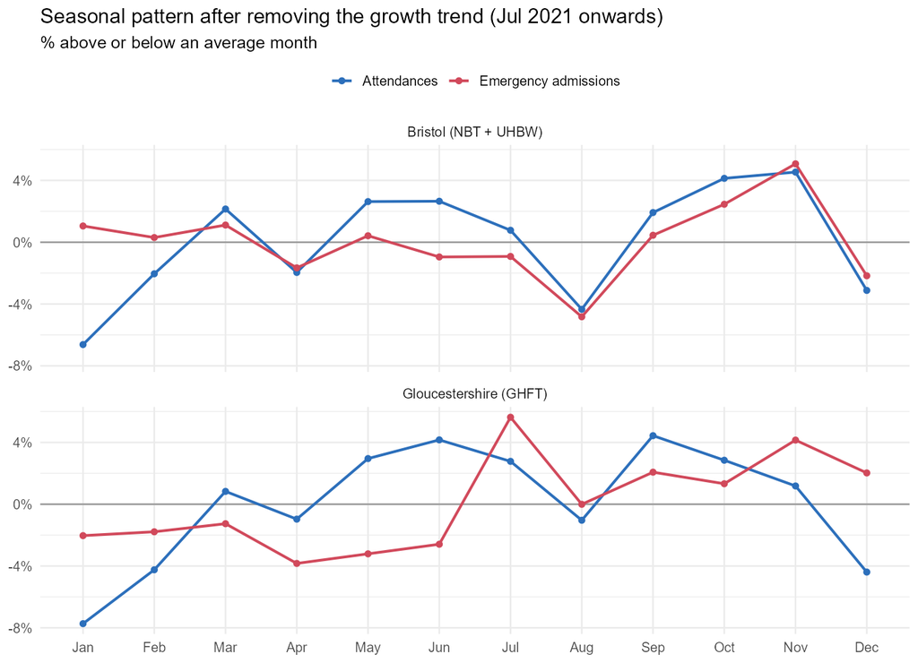

Figure 2: Seasonal pattern after removing the trend: % above or below an average month

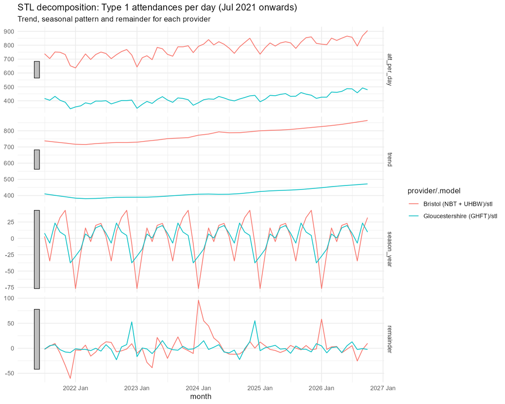

Figure 3: STL decomposition of Type 1 attendances per day

**Limits.** Five post-Covid winters is a short history, so individual month effects are uncertain by a couple of percentage points.

# 4 Question 2: activity plan for 2027-28

## 4.1 Method

- **Training window.** July 2021 onwards. Demand returned after Covid at a different level and mix, so earlier data would mislead the trend, and five winters is enough to estimate monthly seasonality. This was preferred to a Covid dummy variable.
- **Rolling-origin cross-validation.** Each model was trained on the first 36 months, forecast the next 12, then the training window grew by one month and it forecast again: 17 forecast origins, each 12 months ahead. Models were scored on MAPE (mean absolute percentage error) across all of these forecasts, on the error in each 12-month total, and on how often actual months fell inside each model’s 80% and 95% ranges. Many origins, rather than one test year, means the choice does not rest on a single year.
- **Selection rule.** For each trust, the most accurate model (lowest MAPE) whose residuals pass the Ljung-Box test (p > 0.05). A model whose errors still contain a pattern produces over-confident ranges.
- **Honest ranges.** The models’ own ranges include month-to-month noise but not uncertainty in the growth rate. Each trust’s ranges were widened by the factor needed for back-test errors to fall inside them as often as promised, and the annual range is never narrower than the back-tests’ own errors in 12-month totals. The two-trust total’s range is the two trusts’ ranges added, because a bad winter tends to hit both.
- **Forecast.** The chosen model was refitted on all post-Covid data, and 2,000 possible futures were simulated to March 2028.

## 4.2 Model comparison

| Model | MAPE (%) | 1-3 months ahead | 10-12 months ahead | 12-month total error (%) | 12-month total bias (%) | Inside 80% range | Inside 95% range | Ljung-Box p | Chosen |
| --- | --- | --- | --- | --- | --- | --- | --- | --- | --- |
| Bristol (NBT + UHBW) |  |  |  |  |  |  |  |  |  |
| Regression with ARIMA errors | 1.78 | 1.90 | 1.69 | 0.73 | 0.42 | 97% | 100% | 0.425 | Yes |
| Regression: trend + month (TSLM) | 2.16 | 2.31 | 2.13 | 1.34 | 1.33 | 100% | 100% | 0.000 |  |
| ARIMA | 2.48 | 3.00 | 2.00 | 1.59 | 1.48 | 89% | 98% | 0.852 |  |
| ETS | 2.96 | 2.49 | 3.71 | 2.43 | −1.96 | 97% | 100% | 0.237 |  |
| Seasonal naive (baseline) | 3.78 | 3.59 | 3.90 | 2.57 | −2.57 | 95% | 100% | 0.000 |  |
| Gloucestershire (GHFT) |  |  |  |  |  |  |  |  |  |
| Regression: trend + month (TSLM) | 3.74 | 3.33 | 4.24 | 3.46 | −3.46 | 79% | 97% | 0.058 | Yes |
| Regression with ARIMA errors | 3.77 | 3.10 | 4.37 | 3.47 | −3.47 | 72% | 96% | 0.102 |  |
| ETS | 4.47 | 3.80 | 5.63 | 3.12 | −3.05 | 96% | 100% | 0.030 |  |
| ARIMA | 4.98 | 3.78 | 5.99 | 4.56 | −4.56 | 63% | 94% | 0.398 |  |
| Seasonal naive (baseline) | 5.63 | 5.23 | 6.07 | 5.12 | −5.12 | 79% | 95% | 0.106 |  |

Rolling-origin cross-validation: 17 forecast origins, each 12 months ahead. Negative bias = under-forecast.

For Bristol, the regression with ARIMA errors was the most accurate model outright (1.78% MAPE) and its residuals are clean; its 12-month totals were off by only 0.73% on average, and its own ranges proved conservative, so no widening was needed. For Gloucestershire, the trend-plus-month regression won narrowly (3.74% MAPE). **Every Gloucestershire model under-forecast**: the chosen model’s 12-month totals were 3.5% too low on average, consistent with demand there accelerating.

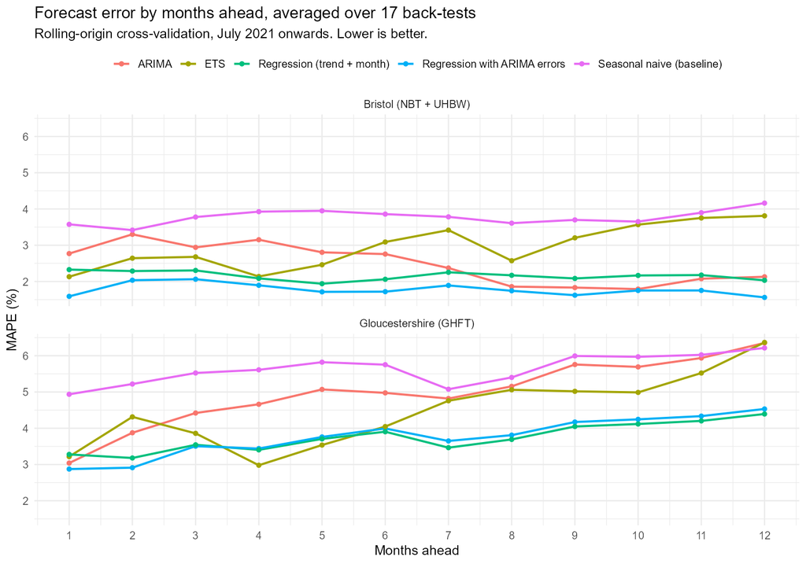

Figure 4: Forecast error by months ahead, averaged over 17 back-tests

## 4.3 The plan

Type 1 A&E attendances, April 2027 to March 2028

| Series | Plan (central) | 80% range | 95% range | Last 12 months (actual) | Change |
| --- | --- | --- | --- | --- | --- |
| Bristol (NBT + UHBW) | 325,400 | 318,700 to 332,000 | 315,000 to 336,000 | 307,632 | 5.8% |
| Gloucestershire (GHFT) | 174,200 | 167,300 to 181,000 | 165,200 to 183,100 | 167,424 | 4.0% |
| Cluster total | 499,600 | 486,000 to 513,100 | 480,200 to 519,100 | 475,056 | 5.2% |

The 80% ranges are about ±2.1% for Bristol, ±3.9% for Gloucestershire and ±2.7% for the two together.

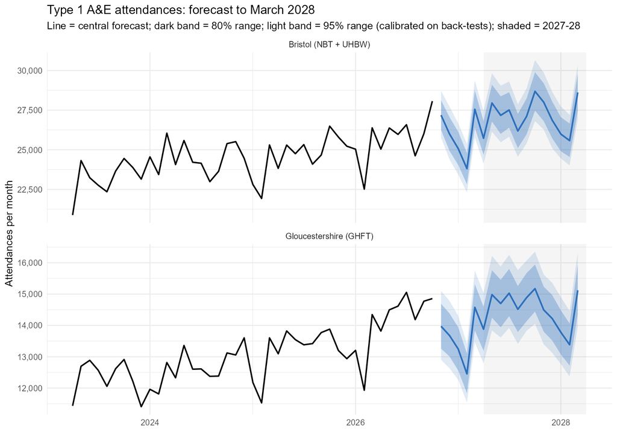

Figure 5: Forecast to March 2028 with 80% and 95% ranges (shaded: 2027-28)

Monthly plan: central forecast (80% range)

| Month | Bristol (NBT + UHBW) | Gloucestershire (GHFT) | Cluster total |
| --- | --- | --- | --- |
| 2027 Apr | 25,730 (24,680-26,820) | 13,880 (13,190-14,600) | 39,600 (37,870-41,420) |
| 2027 May | 27,950 (26,780-29,110) | 14,980 (14,250-15,760) | 42,930 (41,030-44,870) |
| 2027 Jun | 27,170 (26,000-28,370) | 14,700 (13,940-15,460) | 41,870 (39,940-43,830) |
| 2027 Jul | 27,510 (26,390-28,620) | 15,030 (14,290-15,800) | 42,540 (40,690-44,430) |
| 2027 Aug | 26,180 (25,110-27,270) | 14,520 (13,790-15,260) | 40,700 (38,900-42,530) |
| 2027 Sep | 27,100 (25,970-28,230) | 14,890 (14,130-15,670) | 41,990 (40,100-43,900) |
| 2027 Oct | 28,690 (27,470-29,890) | 15,170 (14,440-15,940) | 43,860 (41,910-45,830) |
| 2027 Nov | 28,000 (26,810-29,200) | 14,490 (13,800-15,240) | 42,490 (40,610-44,430) |
| 2027 Dec | 26,870 (25,730-28,050) | 14,220 (13,520-14,970) | 41,090 (39,250-43,020) |
| 2028 Jan | 25,990 (24,900-27,060) | 13,780 (13,070-14,480) | 39,770 (37,980-41,540) |
| 2028 Feb | 25,580 (24,540-26,650) | 13,380 (12,720-14,060) | 38,960 (37,260-40,710) |
| 2028 Mar | 28,620 (27,440-29,770) | 15,120 (14,370-15,930) | 43,740 (41,810-45,700) |

**Limits.** The forecast assumes the post-Covid trend continues; a policy change such as redirecting patients to urgent treatment centres would break it. Gloucestershire’s central figure is more likely too low than too high, given the back-test bias. The back-tests look 1 to 12 months ahead, while 2027-28 is 6 to 17 months ahead, so the later months’ ranges may still be on the narrow side.

# 5 Question 3: what January 2028 demand means for capacity

## 5.1 Model

A discrete-event simulation (R package `simmer`) of Gloucestershire Hospitals’ two Type 1 emergency departments (Gloucestershire Royal and Cheltenham General), **modelled as one combined department**. This overstates how easily staff can move between sites, so results describe a department of this size rather than either site.

Each simulated patient arrives, sees a triage nurse, waits for a clinician, has investigations and treatment, receives a clinician review and decision, and is then discharged or admitted after waiting for a bed. The 4-hour measure is time from arrival to leaving A&E, as in the NHS standard, for Type 1 patients. Each run simulates a whole January (31 days, after 3 warm-up days), and each scenario was run 100 times; the sensitivity runs used 50. Patients still in the department when a run ends count as breaches.

Bed waits follow the three bands Gloucestershire actually reported for January 2026 (under 4 hours, 4 to 12 hours, over 12 hours), with a stated shape inside each band and the longest waits capped at 48 hours.

## 5.2 Assumptions

| Parameter | Value | Source |
| --- | --- | --- |
| Department | GRH + Cheltenham modelled as one combined Type 1 ED | Scoping decision |
| Arrivals (Jan 2028) | 445 per day (95% upper 481) | Forecast, 04_forecast.R |
| Arrival pattern by hour | Low 03:00-06:00, peak 10:00-12:00 | Illustrative; consistent with NHS Digital HES A&E reports |
| Triage | 10 min average; 5 nurses 08:00-22:00, 3 overnight (both sites) | Stated assumption |
| Clinician capacity (modelled) | 22 clinician-equivalents 10:00-22:00, 18 08:00-10:00, 16 22:00-24:00, 12 overnight | Stated assumption; not a headcount |
| Clinician time per patient | 44.1 min average assessment + 10 min review | Calibrated so the model reproduces GHFT's January 2026 Type 1 4-hour performance |
| Investigations / treatment | 90 min average (SD 60), no clinician time | Stated assumption |
| Admission rate | 22.1% | GHFT Type 1, January 2026 (NHS England monthly A&E) |
| Bed wait after decision to admit | 71% under 4h (spread evenly 0-4h), 11% 4-12h (evenly), 19% over 12h (12h + average 6h more, capped at 48h) | Band shares: GHFT DTA waits, January 2026; shapes within bands: stated assumption |
| Patients still in A&E at the end of a run | Counted as 4-hour breaches | Simulation design |
| Replications | 100 simulated Januaries per scenario (50 for sensitivity); 3 warm-up days | Simulation design |

**Calibration.** Real clinician staffing is not published. The model therefore uses a stated **modelled capacity** (22 clinician-equivalents at peak) and calibrates one continuous setting, the clinician time per patient, so that the model reproduces Gloucestershire’s actual January 2026 Type 1 4-hour performance (59.8%). Values from 30 to 60 minutes were each run 20 times; the calibrated value is **44.1 minutes**, which gives 59.9% over 100 checking runs. The 22 is not a headcount: only the combination of capacity and minutes per patient is calibrated.

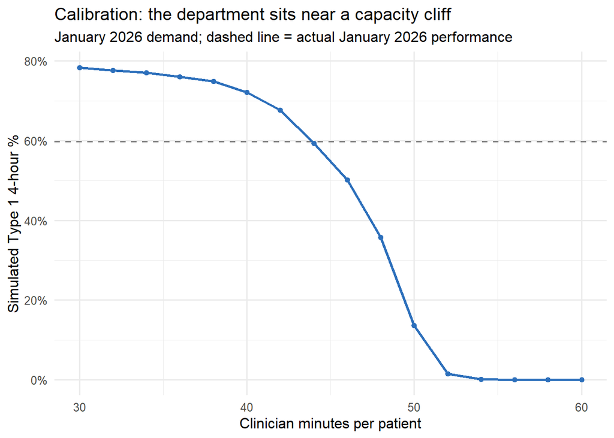

The curve also shows how close to capacity the department runs: a few minutes more per patient takes performance from about 60% towards collapse.

## 5.3 Results

| Scenario | Within 4h | Range across simulated Januaries (95%) | Not admitted | Admitted | Avg wait for clinician (min) | Avg time in A&E (h) |
| --- | --- | --- | --- | --- | --- | --- |
| Jan 2028 forecast, current capacity | 47.6% | 39.7% to 54.7% | 57.7% | 12.0% | 54 | 5.3 |
| Jan 2028 forecast, +1 clinician 10:00-22:00 | 58.6% | 52.7% to 63.9% | 70.7% | 15.9% | 40 | 4.7 |
| Jan 2028 high demand (95% upper), current capacity | 2.7% | 0.0% to 13.3% | 3.3% | 0.5% | 418 | 17.5 |
| Jan 2028 high demand, +1 clinician 10:00-22:00 | 23.3% | 5.5% to 37.0% | 28.5% | 5.3% | 126 | 7.6 |

Type 1 patients, Gloucestershire modelled as one department.

Effect of one extra clinician, 10:00 to 22:00

| Comparison | Gain in 4-hour % (points) | 95% range | Change in wait for clinician (min) | Wait range |
| --- | --- | --- | --- | --- |
| Forecast demand: +1 clinician vs current | 11.1 | 6.5 to 15.3 | -15 | -24 to -8 |
| High demand: +1 clinician vs current | 20.7 | 3.7 to 34.6 | -291 | -522 to -66 |

Paired: each scenario reuses the same simulated patients, so the effect is measured run against run.

- **No change:** demand growth takes Type 1 4-hour performance from about 60% (January 2026) to about 48% in January 2028.
- **One extra clinician, 10:00 to 22:00:** about **11.1 percentage points** better (95% range 6.5 to 15.3), with the average wait for a clinician down by 15 minutes. Most of the gain is for patients who go home; admitted patients still mostly wait for a bed.
- **The extra clinician also helps overnight.** Waits are longest for patients arriving between 22:00 and 02:00, when staffing falls while the evening backlog remains. A daytime clinician shrinks that backlog.
- **High demand** (top of the 95% forecast range) overwhelms the current capacity: the queue grows faster than it clears. Real departments respond with escalation measures this model does not include, so this is a warning rather than a prediction.

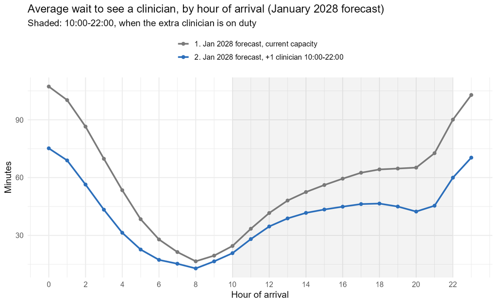

Figure 6: Average wait to see a clinician, by hour of arrival

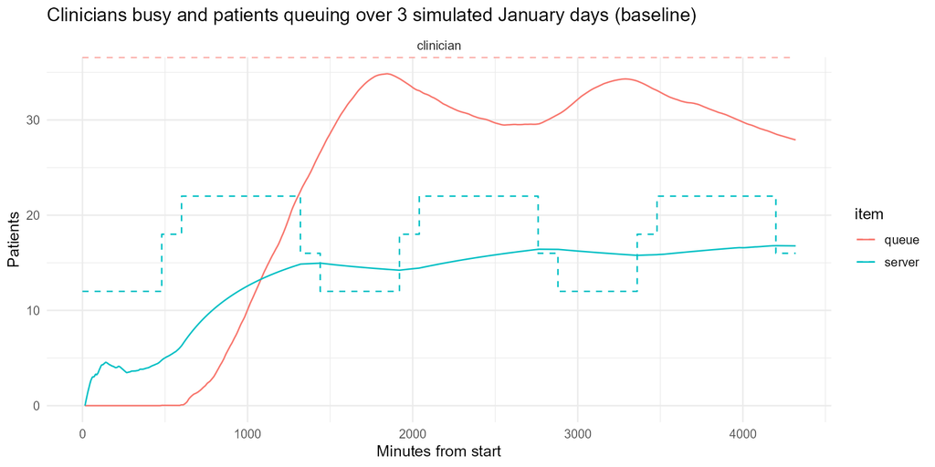

Figure 7: Clinicians busy and patients queuing over three simulated January days (baseline)

## 5.4 Sensitivity

Each assumption was moved 20% up and down with everything else at baseline.

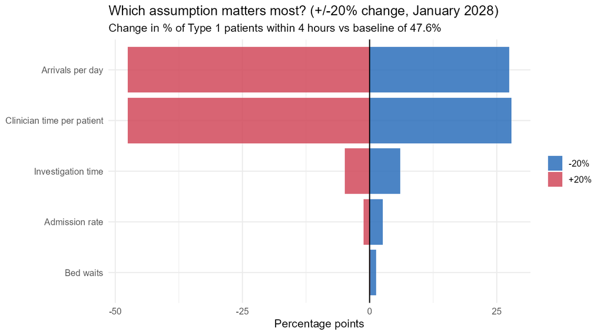

Figure 8: Change in percentage of Type 1 patients within 4 hours when each assumption moves by 20%

| Assumption | -20% | +20% | Swing |
| --- | --- | --- | --- |
| Clinician time per patient | 27.8 | −47.6 | 75.4 |
| Arrivals per day | 27.5 | −47.6 | 75.1 |
| Investigation time | 6.0 | −4.9 | 10.9 |
| Admission rate | 2.6 | −1.2 | 3.8 |
| Bed waits | 1.3 | 0.2 | 1.1 |

Percentage points change in the share of Type 1 patients within 4 hours.

Clinician workload, arrivals multiplied by clinician time per patient, dominates: a 20% change in either moves the result by 75 points from end to end. The result is most sensitive to clinician time per patient, which is calibrated rather than measured and is the first thing to replace with local data. Bed waits matter little here (a 20% change in every bed wait moves the result by only 1.1 points end to end), because most admitted patients already breach 4 hours and, in this model, a patient waiting for a bed does not hold up anyone else. That second point is a known limit, below.

**Limits.** Patients waiting for a bed do not occupy a cubicle in this model; in reality they block space and slow everyone else, so the model still understates the knock-on effect of bed waits. Day-of-week patterns (busy Mondays) and clinician seniority are not modelled, and the two sites are combined. The shapes within each bed-wait band and the 48-hour cap are assumptions.

# 6 Reproducibility

Everything is produced by numbered scripts in `R/`, run in order by `run_all.R`:

| Script | Does |
| --- | --- |
| `00_config.R` | Data cut-off shared by every script |
| `01_download_data.R` | Downloads the monthly CSVs from NHS England (skipped when the frozen files are present) |
| `02_clean_data.R` | Builds the clean Type 1 series per trust |
| `03_explore.R` | Question 1: STL and regression |
| `04_forecast.R` | Question 2: cross-validation, model choice, calibrated ranges and the 2027-28 forecast |
| `05_simulate.R` | Question 3: calibration, scenarios, paired effects and sensitivity |
| `report/report.qmd` | This report |

Package versions are fixed with `renv`, the raw data is frozen at October 2026, and random seeds are fixed, so a rerun reproduces these results:

```r
renv::restore()
source("run_all.R")
```

Built with R version 4.4.2 (2024-10-31 ucrt).